# Project 3: Black-Litterman Model

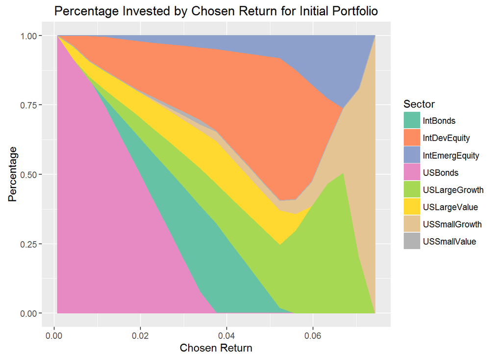

```r
library(quadprog)
library(ggplot2)

# Import covariance matrix
C_Mat <- read.csv("C:/Users/Meggan/Documents/R/optimization/Project3/C_mat.csv",
                  header = FALSE, sep = ",")
C_Mat <- as.matrix(C_Mat)

# Type in historical returns ( m ) as given on handout.
Historical_Returns <- c(.08, .67, 6.41, 4.08, 7.43, 3.7, 4.8, 6.6)/100

# Create name vector for information
Names <- c("USBonds", "IntBonds", "USLargeGrowth", "USLargeValue",
           "USSmallGrowth", "USSmallValue", "IntDevEquity", "IntEmergEquity")
names(Historical_Returns) <- Names
colnames(C_Mat) <- Names
rownames(C_Mat) <- Names

# Create dataframe for the eventual efficient frontier
Efficient_Frontier_One <- data.frame()
Returns <- data.frame(Stock = Names)
Return_vector <- vector()

# Create D Matrix
D_Mat <- 2*C_Mat

# Create A Matrix
Proportion_Vector <- rep(1, length(Historical_Returns))
Diag_Matrix <- diag(1, length(Historical_Returns))
A_Mat <- rbind(Historical_Returns, -Historical_Returns,
               Proportion_Vector, -Proportion_Vector, Diag_Matrix)

# Create D_Vector
D_Vector <- rep(0, length(Historical_Returns))

# Create starting point for estimated returns (cycle through for many returns)
ret <- min(Historical_Returns)

# How many points in between we would like from min return to max return
Number_Of_Points <- 20

# Create vectors to create stacked area proportion chart
Chosen_Return <- vector()
Percentage <- vector()

# While loop to run program and get back many returns
while(ret <= max(Historical_Returns)) {

  # Create B_Vector
  B_Vec <- c(ret, -ret, 1, -1, rep(0, length(Historical_Returns)))

  # Run QP
  sol <- solve.QP(D_Mat, D_Vector, t(A_Mat), B_Vec)

  # Put Standard Deviation and Expected Return into a data frame for plotting
  Portfolio_Standard_Deviation <- sqrt(sol$value)
  Portfolio_Expected_Return <- sum(Historical_Returns*sol$solution)
  Efficient_Frontier_One <- rbind(c(Portfolio_Expected_Return,
                                Portfolio_Standard_Deviation),
                              Efficient_Frontier_One)
  colnames(Efficient_Frontier_One) <- c("Estimated_Return", "Std_Deviation")

  # Creating Stacked Area Chart data
  Chosen_Return <- append(rep(ret, length(sol$solution)), Chosen_Return)
  Percentage <- append(sol$solution, Percentage)

  # Add to index variable
  ret <- ret + (max(Historical_Returns) - min(Historical_Returns))/Number_Of_Points
}

# Sector variable for stacked area chart
Sector <- rep(Names, (Number_Of_Points)+1)

# Dataframe for stacked area chart
df <- data.frame(Sector,Chosen_Return,Percentage)

# Plot stacked area chart
gg <- ggplot(df, aes(x=Chosen_Return, y=Percentage))
gg <- gg + geom_area(aes(colour=Sector, fill=Sector)) +
  ylab("Percentage") +
  xlab("Chosen Return") +
  scale_fill_brewer(palette = "Set2") +
  scale_color_brewer(palette = "Set2") +
  ggtitle("Percentage Invested by Chosen Return for Initial Portfolio")
gg
```

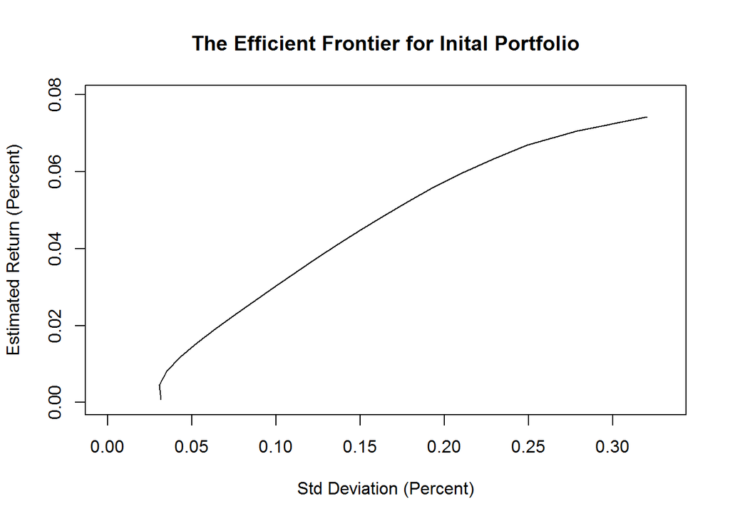

```r
# Plot All of the returns
plot(Efficient_Frontier_One[[2]], Efficient_Frontier_One[[1]],
     xlab = "Std Deviation (Percent)",
     ylab = "Estimated Return (Percent)",
     main = "The Efficient Frontier for Inital Portfolio", type = "l",
     xlim = c(0, (max(Efficient_Frontier_One[[2]] + .01))),
     ylim = c(0, (max(Efficient_Frontier_One[[1]]+.005))))
```

```r
# Minimum variance for return of 1%
round(Efficient_Frontier_One[nrow(Efficient_Frontier_One),], 3)*100
```

```
##    Estimated_Return Std_Deviation
## 21              0.1           3.2
```

```r
# Creating the Blck-Litterman Model
P_Matrix <- matrix(c(0, 0, 0, 0, 0, 1, 0, 0,
                     0, 0, 0, 0, 0, 0, -1, 1,
                     0, 0, -1, 0, 1, 0, 0, 0), nrow = 3,byrow = TRUE)
Q_Vec <- c(6.1, 3, .2)/100
tau = 1
Omega <- diag(1, 3)*c(.000801, .009546, .000884)

# Solve m_hat formula
m_hat <- as.vector(solve(solve(tau*C_Mat) +t(P_Matrix)%*%solve(Omega)%*%P_Matrix) %*% (solve(tau*C_Mat)%*%Historical_Returns + t(P_Matrix)%*%solve(Omega)%*%Q_Vec))
m_hat
```

```
## [1] 0.0002972091 0.0059122626 0.0915081503 0.0697977184 0.0943455442
## [6] 0.0600042354 0.0670967396 0.0956883152
```

```r
names(Historical_Returns) <- NULL
Historical_Returns
```

```
## [1] 0.0008 0.0067 0.0641 0.0408 0.0743 0.0370 0.0480 0.0660
```

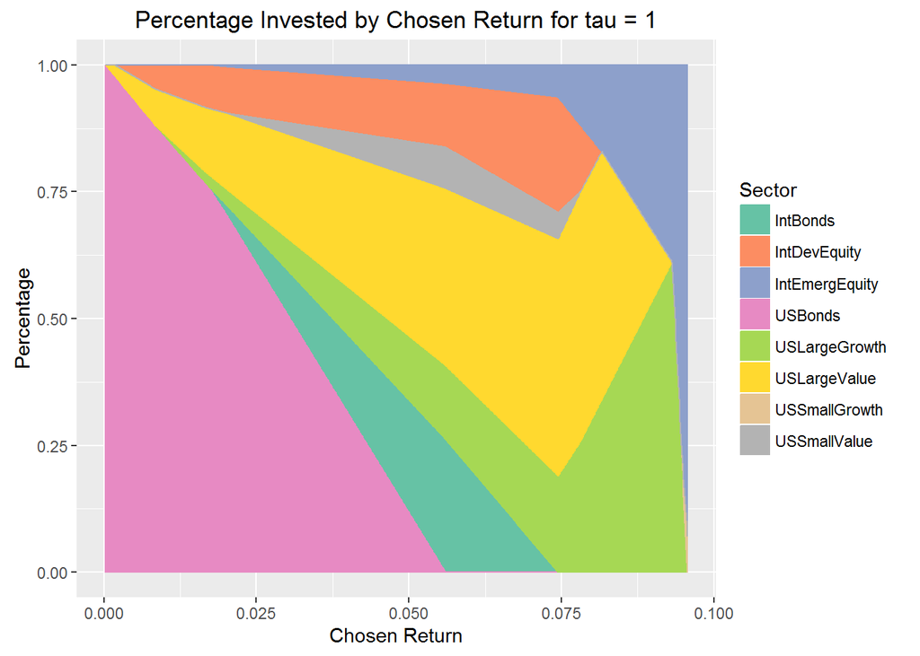

```r
# Give m_hat names for cleanliness
names(m_hat) <- Names

# Re-do A_Matrix for new m_vector
Proportion_Vector <- rep(1, length(m_hat))
Diag_Matrix <- diag(1, length(m_hat))
A_Mat <- rbind(m_hat, -m_hat, Proportion_Vector, -Proportion_Vector, Diag_Matrix)


# Create dataframe for the eventual efficient frontier
Efficient_Frontier_Two <- data.frame()


# Create vectors for stacked area chart
Chosen_Return <- vector()
Percentage <- vector()

# Set desired return to the minimum of estimated returns
ret <- min(m_hat)
Number_Of_Points <- 1001
while(ret <= max(m_hat)) {

  # Create B_Vector
  B_Vec <- c(ret, -ret, 1, -1, rep(0, length(m_hat)))

  # Run QP
  sol <- solve.QP(D_Mat, D_Vector, t(A_Mat), B_Vec)

  # Put Standard Deviation and Expected Return into a data frame for plotting
  Portfolio_Standard_Deviation <- sqrt(sol$value)
  Portfolio_Expected_Return <- sum(m_hat*sol$solution)
  Efficient_Frontier_Two <- rbind(c(Portfolio_Expected_Return,
                                Portfolio_Standard_Deviation),
                                Efficient_Frontier_Two)
  colnames(Efficient_Frontier_Two) <- c("Estimated Return", "Std Deviation")

  # Creating Stacked Area Chart
  Chosen_Return <- append(rep(ret, length(sol$solution)), Chosen_Return)
  Percentage <- append(sol$solution, Percentage)


  # Add to index variable
  ret <- ret + (max(m_hat) - min(m_hat))/Number_Of_Points
}

Sector <- rep(Names, (Number_Of_Points))

df <- data.frame(Sector,Chosen_Return,Percentage)

gg <- ggplot(df, aes(x=Chosen_Return, y=Percentage))
gg <- gg + geom_area(aes(colour=Sector, fill=Sector)) +
  ylab("Percentage") +
  xlab("Chosen Return")
gg  + scale_fill_brewer(palette = "Set2") + scale_color_brewer(palette = "Set2") + ggtitle("Percentage Invested by Chosen Return for tau = 1")
```

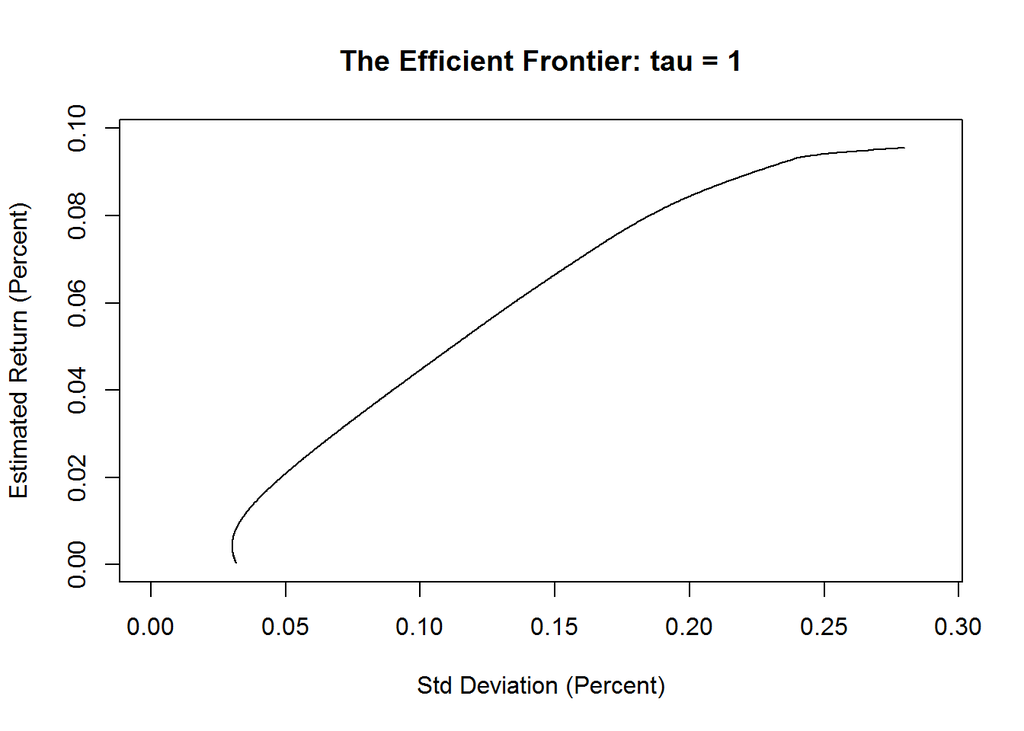

```r
# Plot All of the returns
plot(Efficient_Frontier_Two[[2]], Efficient_Frontier_Two[[1]],
     xlab = "Std Deviation (Percent)",
     ylab = "Estimated Return (Percent)",
     main = "The Efficient Frontier: tau = 1",
     type = "l",
     xlim = c(0, (max(Efficient_Frontier_Two[[2]] + 1/100))),
     ylim = c(0, (max(Efficient_Frontier_Two[[1]]+.25/100))))
```

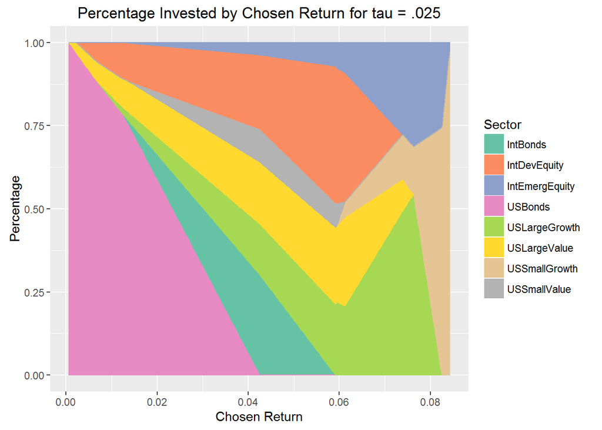

```r
# Creating the Blck-Litterman Model
P_Matrix <- matrix(c(0, 0, 0, 0, 0, 1, 0, 0,
                     0, 0, 0, 0, 0, 0, -1, 1,
                     0, 0, -1, 0, 1, 0, 0, 0), nrow = 3,byrow = TRUE)
Q_Vec <- c(6.1, 3, .2)/100
tau = .025

Omega <- diag(1, 3)*c(.000801, .009546, .000884)

# Solve m_hat formula
m_hat <- as.vector(solve(solve(tau*C_Mat) +
                   t(P_Matrix)%*%solve(Omega)%*%P_Matrix)%*%
                   (solve(tau*C_Mat)%*%Historical_Returns +
                   t(P_Matrix)%*%solve(Omega)%*%Q_Vec))


# Give m_hat names for cleanliness
names(m_hat) <- Names

# Re-do A_Matrix for new m_vector
Proportion_Vector <- rep(1, length(m_hat))
Diag_Matrix <- diag(1, length(m_hat))
A_Mat <- rbind(m_hat, -m_hat, Proportion_Vector, -Proportion_Vector, Diag_Matrix)


# Create dataframe for the eventual efficient frontier
Efficient_Frontier_Three <- data.frame()


# Create vectors for stacked area chart
Chosen_Return <- vector()
Percentage <- vector()

# Set desired return to the minimum of estimated returns
ret <- min(m_hat)
Number_Of_Points <- 401
while(ret <= max(m_hat)) {

  # Create B_Vector
  B_Vec <- c(ret, -ret, 1, -1, rep(0, length(m_hat)))

  # Run QP
  sol <- solve.QP(D_Mat, D_Vector, t(A_Mat), B_Vec)

  # Put Standard Deviation and Expected Return into a data frame for plotting
  Portfolio_Standard_Deviation <- sqrt(sol$value)
  Portfolio_Expected_Return <- sum(m_hat*sol$solution)
  Efficient_Frontier_Three <- rbind(c(Portfolio_Expected_Return,
                                Portfolio_Standard_Deviation),
                                Efficient_Frontier_Three)
  colnames(Efficient_Frontier_Three) <- c("Estimated Return", "Std Deviation")

  # Creating Stacked Area Chart
  Chosen_Return <- append(rep(ret, length(sol$solution)), Chosen_Return)
  Percentage <- append(sol$solution, Percentage)


  # Add to index variable
  ret <- ret + (max(m_hat) - min(m_hat))/Number_Of_Points
}

Sector <- rep(Names, (Number_Of_Points))

df <- data.frame(Sector,Chosen_Return,Percentage)

gg <- ggplot(df, aes(x=Chosen_Return, y=Percentage))
gg <- gg + geom_area(aes(colour=Sector, fill=Sector)) +
  ylab("Percentage") +
  xlab("Chosen Return") +
  ggtitle("Percentage Invested by Chosen Return for tau = .025")

gg  + scale_fill_brewer(palette = "Set2") + scale_color_brewer(palette = "Set2")
```

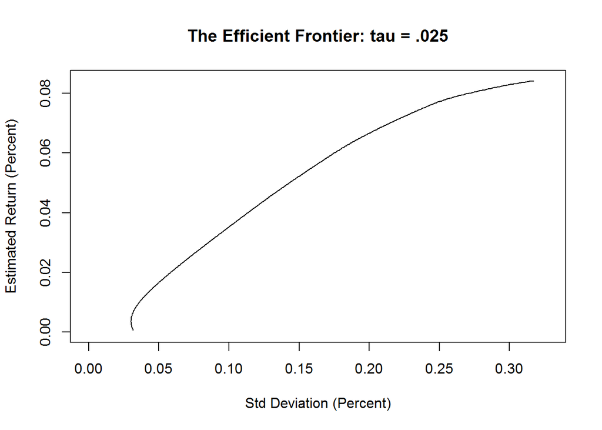

```r
# Plot All of the returns
plot(Efficient_Frontier_Three[[2]], Efficient_Frontier_Three[[1]],
     xlab = "Std Deviation (Percent)",
     ylab = "Estimated Return (Percent)",
     main = "The Efficient Frontier: tau = .025",
     type = "l",
     xlim = c(0, (max(Efficient_Frontier_Three[[2]] + 1/100))),
     ylim = c(0, (max(Efficient_Frontier_Three[[1]]+.01/100))))
```

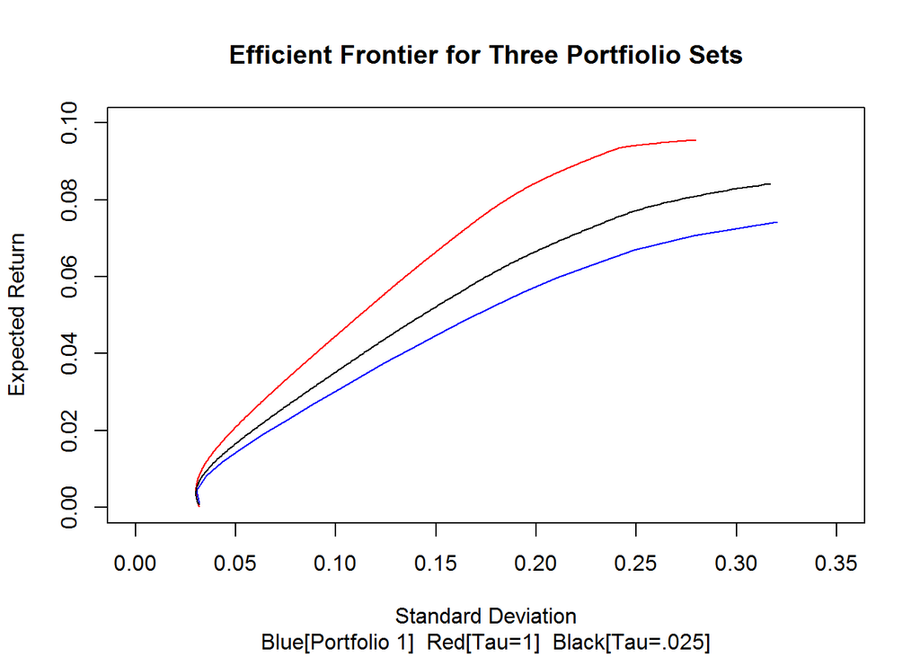

```r
plot(Efficient_Frontier_One$Std_Deviation, Efficient_Frontier_One$Estimated_Return, type = "l", col = "blue", sub = "Blue[Portfolio 1]  Red[Tau=1]  Black[Tau=.025]", ylim = c(0, .10), xlim = c(0, .35), main = "Efficient Frontier for Three Portfiolio Sets", xlab = "Standard Deviation", ylab = "Expected Return")

points(Efficient_Frontier_Two$`Std Deviation`, Efficient_Frontier_Two$`Estimated Return`, type = "l", col = "red")

points(Efficient_Frontier_Three$`Std Deviation`, Efficient_Frontier_Three$`Estimated Return`, type = "l")
```

The Black-Litterman model allows us to express views either in relative or absolute terms. These views are set in the P matrix, where we write a series of relationships to describe a particular view. For example, the first view is an absolute view: $x_6 = .061$ says a US Small Value will have a 6.1% premium. The second view is relative: $-x_7 + x_8 = .03$ requires International Emerging Equity to be larger than International Devoped Equity by 3%, though the specific numbers can vary as long as the difference remains the same. The resulting solution $\hat{m}$ appears to be a weighted average of our view and the historical returns.

If $\tau$ is very small, the views we express in the P matrix will be weighted less into the model. If one chooses $\tau$ of .001, the efficient frontier will nearly resemble the efficient frontier for the initial portfolio. The smaller tau is, the more weight is given to the historical returns. This is because when we multiply a small scaler by a matrix, then solve for the inverse, the resulting matrix is large. This large matrix is then multiplied by the historical returns. An example of how a small scaler creates a larger matrix when the inverse is taken is shown below.

```r
sum(solve(.001*C_Mat))
```

```
## [1] 1179687
```

```r
sum(solve(5*C_Mat))
```

```
## [1] 235.9373
```

It is also worth noting that the efficient frontier for $\tau$ = 1 is nearly the same as $\tau$ = 100 and so appears that decent range for $\tau$ might be somewhere between .1 and .5. The greater $\tau$ is, the further to the northwest the efficient frontier moves because we have stated that we believe US Small Value with have a greater return than the historical returns tell us. If we decided to state that $x_6 = -.01$ then the efficient frontier would decrease given that returns are expected to be lower.